# CARS4U PROJECT

## Context

#### There is a huge demand for used cars in the Indian Market today. As sales of new cars have slowed down in the recent past, the pre-owned car market has continued to grow over the past years and is larger than the new car market now. Cars4U is a budding tech start-up that aims to find footholes in this market.

#### In 2018-19, while new car sales were recorded at 3.6 million units, around 4 million second-hand cars were bought and sold. There is a slowdown in new car sales and that could mean that the demand is shifting towards the pre-owned market. In fact, some car sellers replace their old cars with pre-owned cars instead of buying new ones. Unlike new cars, where price and supply are fairly deterministic and managed by OEMs (Original Equipment Manufacturer / except for dealership level discounts which come into play only in the last stage of the customer journey), used cars are very different beasts with huge uncertainty in both pricing and supply. Keeping this in mind, the pricing scheme of these used cars becomes important in order to grow in the market.

#### As a senior data scientist at Cars4U, you have to come up with a pricing model that can effectively predict the price of used cars and can help the business in devising profitable strategies using differential pricing. For example, if the business knows the market price, it will never sell anything below it.

## Objective

#### To explore and visualize the dataset, build a linear regression model to predict the prices of used cars, and generate a set of insights and recommendations that will help the business.

## Data Description

#### The data contains the different attributes of used cars sold in different locations. The detailed data dictionary is given below.

## Data Dictionary

#### S.No.: Serial number

#### Name: Name of the car which includes brand name and model name

#### Location: Location in which the car is being sold or is available for purchase (cities)

#### Year: Manufacturing year of the car

#### Kilometers_driven: The total kilometers driven in the car by the previous owner(s) in km

#### Fuel_Type: The type of fuel used by the car (Petrol, Diesel, Electric, CNG, LPG)

#### Transmission: The type of transmission used by the car (Automatic/Manual)

#### Owner: Type of ownership

#### Mileage: The standard mileage offered by the car company in kmpl or km/kg

#### Engine: The displacement volume of the engine in CC

#### Power: The maximum power of the engine in bhp

#### Seats: The number of seats in the car

#### New_Price: The price of a new car of the same model in INR Lakhs (1 Lakh INR = 100,000 INR)

#### Price: The price of the used car in INR Lakhs

```python
# Let's import relevant libraries


# this will help in making the Python code more structured automatically
%load_ext nb_black

# Libraries to help with reading and manipulating data
import pandas as pd
import numpy as np

# Libraries to help with data visualization
import matplotlib.pyplot as plt
import seaborn as sns

%matplotlib inline
sns.set(color_codes=True)


pd.set_option(
    "display.max_columns", None
)  # Removes the limit for the number of displayed columns
pd.set_option(
    "display.max_rows", 200
)  # Sets the limit for the number of displayed rows

from sklearn.model_selection import (
    train_test_split,
)  # to split the data into train and test
from sklearn.linear_model import LinearRegression  # to build linear regression_model
from sklearn.metrics import (
    mean_absolute_error,
    mean_squared_error,
    r2_score,
)  # to check model performance

# To filter warnings
import warnings

warnings.filterwarnings("ignore")
```

```python
# Let's read the dataset to work with
df_used_cars = pd.read_csv("used_cars_data.csv")
df_used_cars
```

|  | S.No. | Name | Location | Year | Kilometers_Driven | Fuel_Type | Transmission | Owner_Type | Mileage | Engine | Power | Seats | New_Price | Price |
| --- | --- | --- | --- | --- | --- | --- | --- | --- | --- | --- | --- | --- | --- | --- |
| 0 | 0 | Maruti Wagon R LXI CNG | Mumbai | 2010 | 72000 | CNG | Manual | First | 26.6 km/kg | 998 CC | 58.16 bhp | 5.0 | NaN | 1.75 |
| 1 | 1 | Hyundai Creta 1.6 CRDi SX Option | Pune | 2015 | 41000 | Diesel | Manual | First | 19.67 kmpl | 1582 CC | 126.2 bhp | 5.0 | NaN | 12.50 |
| 2 | 2 | Honda Jazz V | Chennai | 2011 | 46000 | Petrol | Manual | First | 18.2 kmpl | 1199 CC | 88.7 bhp | 5.0 | 8.61 Lakh | 4.50 |
| 3 | 3 | Maruti Ertiga VDI | Chennai | 2012 | 87000 | Diesel | Manual | First | 20.77 kmpl | 1248 CC | 88.76 bhp | 7.0 | NaN | 6.00 |
| 4 | 4 | Audi A4 New 2.0 TDI Multitronic | Coimbatore | 2013 | 40670 | Diesel | Automatic | Second | 15.2 kmpl | 1968 CC | 140.8 bhp | 5.0 | NaN | 17.74 |
| ... | ... | ... | ... | ... | ... | ... | ... | ... | ... | ... | ... | ... | ... | ... |
| 7248 | 7248 | Volkswagen Vento Diesel Trendline | Hyderabad | 2011 | 89411 | Diesel | Manual | First | 20.54 kmpl | 1598 CC | 103.6 bhp | 5.0 | NaN | NaN |
| 7249 | 7249 | Volkswagen Polo GT TSI | Mumbai | 2015 | 59000 | Petrol | Automatic | First | 17.21 kmpl | 1197 CC | 103.6 bhp | 5.0 | NaN | NaN |
| 7250 | 7250 | Nissan Micra Diesel XV | Kolkata | 2012 | 28000 | Diesel | Manual | First | 23.08 kmpl | 1461 CC | 63.1 bhp | 5.0 | NaN | NaN |
| 7251 | 7251 | Volkswagen Polo GT TSI | Pune | 2013 | 52262 | Petrol | Automatic | Third | 17.2 kmpl | 1197 CC | 103.6 bhp | 5.0 | NaN | NaN |
| 7252 | 7252 | Mercedes-Benz E-Class 2009-2013 E 220 CDI Avan... | Kochi | 2014 | 72443 | Diesel | Automatic | First | 10.0 kmpl | 2148 CC | 170 bhp | 5.0 | NaN | NaN |

7253 rows × 14 columns

#### Observation: The dataset looks consistent with the description provided in the Data Dictionary. However, Name column contains a lot of texts while Mileage, Engine, Power, and New_Price have mixture of numbers and texts.

```python
df = df_used_cars.copy() #To keep a copy of the original data
```

```python
df.shape  # To check the shape of the dataset
```

```
(7253, 14)
```

#### Observation: The dataset contains 7253 rows and 14 columns

```python
df.duplicated().sum()  # To check for duplicated row in the dataset
```

```
0
```

#### Observation: The dataset has no duplicated row.

```python
df.sample(20, random_state=2)
```

|  | S.No. | Name | Location | Year | Kilometers_Driven | Fuel_Type | Transmission | Owner_Type | Mileage | Engine | Power | Seats | New_Price | Price |
| --- | --- | --- | --- | --- | --- | --- | --- | --- | --- | --- | --- | --- | --- | --- |
| 4584 | 4584 | Tata Tigor 1.05 Revotorq XT | Kochi | 2018 | 28973 | Diesel | Manual | First | 24.7 kmpl | 1047 CC | 69 bhp | 5.0 | NaN | 6.64 |
| 6505 | 6505 | Volkswagen Vento Diesel Highline | Chennai | 2011 | 76041 | Diesel | Manual | First | 20.54 kmpl | 1598 CC | 103.6 bhp | 5.0 | NaN | NaN |
| 3675 | 3675 | Maruti Swift VDI | Ahmedabad | 2012 | 65000 | Diesel | Manual | First | 22.9 kmpl | 1248 CC | 74 bhp | 5.0 | NaN | 3.90 |
| 5654 | 5654 | Hyundai i20 Magna Optional 1.2 | Kochi | 2014 | 42315 | Petrol | Manual | First | 18.5 kmpl | 1197 CC | 82.9 bhp | 5.0 | NaN | 4.79 |
| 4297 | 4297 | Toyota Camry 2.5 G | Mumbai | 2014 | 68400 | Petrol | Automatic | First | 12.98 kmpl | 2494 CC | 178.4 bhp | 5.0 | NaN | 13.50 |
| 2603 | 2603 | Mercedes-Benz New C-Class 220 CDI AT | Jaipur | 2010 | 74213 | Diesel | Automatic | First | 14.84 kmpl | 2143 CC | 170 bhp | 5.0 | NaN | 11.50 |
| 4337 | 4337 | Volkswagen Vento Petrol Highline AT | Kochi | 2014 | 32283 | Petrol | Automatic | Second | 14.4 kmpl | 1598 CC | 103.6 bhp | 5.0 | NaN | 5.41 |
| 6625 | 6625 | Maruti Swift VDI BSIV | Kolkata | 2012 | 72000 | Diesel | Manual | First | 17.8 kmpl | 1248 CC | NaN | 5.0 | NaN | NaN |
| 2846 | 2846 | Skoda Superb Elegance 1.8 TSI AT | Kochi | 2011 | 73783 | Petrol | Automatic | Second | 13.7 kmpl | 1798 CC | 157.75 bhp | 5.0 | NaN | 5.23 |
| 1237 | 1237 | Audi Q3 2.0 TDI Quattro | Hyderabad | 2013 | 60000 | Diesel | Automatic | First | 17.32 kmpl | 1968 CC | 184 bhp | 5.0 | NaN | 21.00 |
| 849 | 849 | Audi A6 3.0 TDI quattro | Coimbatore | 2009 | 48040 | Diesel | Automatic | Second | 16.77 kmpl | 2967 CC | 241.38 bhp | 5.0 | NaN | 12.07 |
| 6914 | 6914 | Hyundai i20 1.4 CRDi Magna | Hyderabad | 2013 | 65461 | Diesel | Manual | First | 21.9 kmpl | 1396 CC | 90 bhp | 5.0 | NaN | NaN |
| 5873 | 5873 | Hyundai Santro Xing XO eRLX Euro II | Pune | 2006 | 47200 | Petrol | Manual | Second | 17.0 kmpl | 1086 CC | NaN | 5.0 | NaN | 1.20 |
| 6720 | 6720 | Tata Indica Vista TDI LS | Hyderabad | 2013 | 132000 | Diesel | Manual | Second | 19.4 kmpl | 1405 CC | 70 bhp | 5.0 | NaN | NaN |
| 37 | 37 | Mahindra KUV 100 mFALCON G80 K6 5str AW | Delhi | 2017 | 52000 | Petrol | Manual | First | 18.15 kmpl | 1198 CC | 82 bhp | 5.0 | NaN | 4.85 |
| 1526 | 1526 | Skoda Yeti Ambition 4X2 | Hyderabad | 2012 | 99754 | Diesel | Manual | First | 17.72 kmpl | 1968 CC | 108.49 bhp | 5.0 | NaN | 7.99 |
| 5591 | 5591 | Honda Civic 2006-2010 1.8 S MT | Pune | 2006 | 125000 | Petrol | Manual | Second | 13.5 kmpl | 1799 CC | 130 bhp | 5.0 | NaN | 2.30 |
| 2675 | 2675 | Maruti Wagon R VXi BSII | Pune | 2012 | 82000 | Petrol | Manual | First | 18.9 kmpl | 998 CC | 67.1 bhp | 5.0 | NaN | 2.30 |
| 2995 | 2995 | Hyundai i10 Magna AT | Bangalore | 2008 | 58483 | Petrol | Automatic | Second | 19.2 kmpl | 1197 CC | 80 bhp | 5.0 | NaN | 2.95 |
| 2063 | 2063 | Honda Amaze VX i-Vtech | Pune | 2013 | 47000 | Petrol | Manual | First | 18.0 kmpl | 1198 CC | 86.7 bhp | 5.0 | NaN | 4.15 |

#### Looking at the columns data, it is obvious we do not need 'S.No' column at all as it contains no data relevant to the project objective but only replicate the data index. Therefore let's drop it now

```python
df.drop(["S.No."], axis=1, inplace=True)  # To drop 'S.No' column
```

```python
# Let's check the remaining columns in the dataframe
df.columns
```

```
Index(['Name', 'Location', 'Year', 'Kilometers_Driven', 'Fuel_Type',
       'Transmission', 'Owner_Type', 'Mileage', 'Engine', 'Power', 'Seats',
       'New_Price', 'Price'],
      dtype='object')
```

```python
df.info()  # To print the concise summary of the data set
```

```
<class 'pandas.core.frame.DataFrame'>
RangeIndex: 7253 entries, 0 to 7252
Data columns (total 13 columns):
 #   Column             Non-Null Count  Dtype
---  ------             --------------  -----
 0   Name               7253 non-null   object
 1   Location           7253 non-null   object
 2   Year               7253 non-null   int64
 3   Kilometers_Driven  7253 non-null   int64
 4   Fuel_Type          7253 non-null   object
 5   Transmission       7253 non-null   object
 6   Owner_Type         7253 non-null   object
 7   Mileage            7251 non-null   object
 8   Engine             7207 non-null   object
 9   Power              7078 non-null   object
 10  Seats              7200 non-null   float64
 11  New_Price          1006 non-null   object
 12  Price              6019 non-null   float64
dtypes: float64(2), int64(2), object(9)
memory usage: 736.8+ KB
```

#### Observations:

#### Name, Location,Fuel_Type,Transmission, Owner_Type,Mileage,Engine and Power contain object data type which make them categorical while others contains integer and float data types

#### However, Mileage,Engine and Power should be numerical variables here. This will be worked upon later in the project. Also, 'Year' data will be converted to Car_Age variable later in this project for better analysis but and 'Seats' will be converted to categorical variable as it speaks more to car classification than being a float data type.

#### From the summary above, it is glaring that some columns indexes contain 7253 observations each while some are not. This means that there are missing values in the data set. We will further confirm this now

```python
df.isnull().sum()  # To check for missing values in the dataset
```

```
Name                    0
Location                0
Year                    0
Kilometers_Driven       0
Fuel_Type               0
Transmission            0
Owner_Type              0
Mileage                 2
Engine                 46
Power                 175
Seats                  53
New_Price            6247
Price                1234
dtype: int64
```

#### Observation: Mileage, Engine, Power, Seats, New_Price, and Price all contain missing values. Worthy of note is the level of missingness in New_Price which is more than 85% of the total obersavtions. The reason for this might be that the price of new cars are not readily obtainable in Cars4U environment or there are serious difficulties in obtaining them. In order not to build a false model, it is advisable we drop the New_Price column now. Later, we will also drop all the rows containing the missing number in the target variable(Price) while we fill the missing numbers in Mileage, Engine, Power, and Seats with the median of each column

```python
df.drop(
    "New_Price", axis=1, inplace=True
)  # To drop the New_Price column because of the level of missingness
```

```python
df.sample(5)  # To sample 5 rows from the data set
```

|  | Name | Location | Year | Kilometers_Driven | Fuel_Type | Transmission | Owner_Type | Mileage | Engine | Power | Seats | Price |
| --- | --- | --- | --- | --- | --- | --- | --- | --- | --- | --- | --- | --- |
| 430 | Honda Brio S MT | Delhi | 2014 | 30000 | Petrol | Manual | Second | 19.4 kmpl | 1198 CC | 86.8 bhp | 5.0 | 3.20 |
| 2272 | Ford Figo Diesel Titanium | Pune | 2011 | 95000 | Diesel | Manual | Third | 20.0 kmpl | 1399 CC | 68 bhp | 5.0 | 2.35 |
| 1957 | Honda Mobilio S i DTEC | Kochi | 2015 | 50624 | Diesel | Manual | First | 24.2 kmpl | 1498 CC | 98.6 bhp | 7.0 | 6.32 |
| 4833 | Mercedes-Benz E-Class 280 CDI | Mumbai | 2005 | 131000 | Diesel | Automatic | First | 11.0 kmpl | 2987 CC | 198.5 bhp | 5.0 | 10.00 |
| 6569 | BMW X6 xDrive30d | Hyderabad | 2011 | 76000 | Diesel | Automatic | First | 11.2 kmpl | 2993 CC | 241 bhp | 4.0 | NaN |

## Now Let's process each column to the right shape based on the Project objective

## Name

#### Considering the fact that car names in the data contains a lot of text describing the car brand and model, we will be reducing the names to the first word that begins each name. This will give us the car brand which from natural knowledge plays a role in the pricing of cars

```python
df["Name"] = df.Name.apply(
    lambda x: x.split(" ")[0]
)  # To split the Name column and return only the first word
```

```python
df.Name.value_counts()  # To check the frequencies of the Name unique vales
```

```
Maruti           1444
Hyundai          1340
Honda             743
Toyota            507
Mercedes-Benz     380
Volkswagen        374
Ford              351
Mahindra          331
BMW               312
Audi              285
Tata              228
Skoda             202
Renault           170
Chevrolet         151
Nissan            117
Land               67
Jaguar             48
Fiat               38
Mitsubishi         36
Mini               31
Volvo              28
Porsche            19
Jeep               19
Datsun             17
ISUZU               3
Force               3
Isuzu               2
Bentley             2
Smart               1
Ambassador          1
Lamborghini         1
Hindustan           1
OpelCorsa           1
Name: Name, dtype: int64
```

#### Observation: It is observed that car brand 'Maruti' is the mostly sold used car followed by Hyundai. Also, Isuzu car name appears twice as ISUZU and Isuzu. This needs to be merged into one name by converting the two names into title case and we shall do this now.

```python
df["Name"] = df.Name.str.title()  # To convert all names to title case
```

```
Maruti           1444
Hyundai          1340
Honda             743
Toyota            507
Mercedes-Benz     380
Volkswagen        374
Ford              351
Mahindra          331
Bmw               312
Audi              285
Tata              228
Skoda             202
Renault           170
Chevrolet         151
Nissan            117
Land               67
Jaguar             48
Fiat               38
Mitsubishi         36
Mini               31
Volvo              28
Porsche            19
Jeep               19
Datsun             17
Isuzu               5
Force               3
Bentley             2
Smart               1
Ambassador          1
Lamborghini         1
Hindustan           1
Opelcorsa           1
Name: Name, dtype: int64
AxesSubplot(0.125,0.125;0.775x0.755)
```

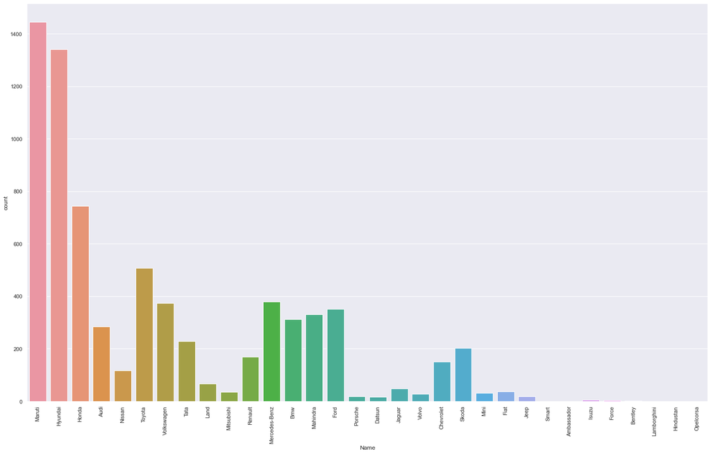

```python
plt.figure(figsize=(25, 15))
print(
    df.Name.value_counts()
)  # To check the frequencies of the Name unique values again to confirm if Isuzu repetition has been taken care of
plt.xticks(rotation=90)
print(sns.countplot(df.Name))  # To visualise the distribution
```

#### Observation: It works well as the Isuzu car name is now one

## Location

```
Mumbai        949
Hyderabad     876
Coimbatore    772
Kochi         772
Pune          765
Delhi         660
Kolkata       654
Chennai       591
Jaipur        499
Bangalore     440
Ahmedabad     275
Name: Location, dtype: int64
AxesSubplot(0.125,0.125;0.775x0.755)
```

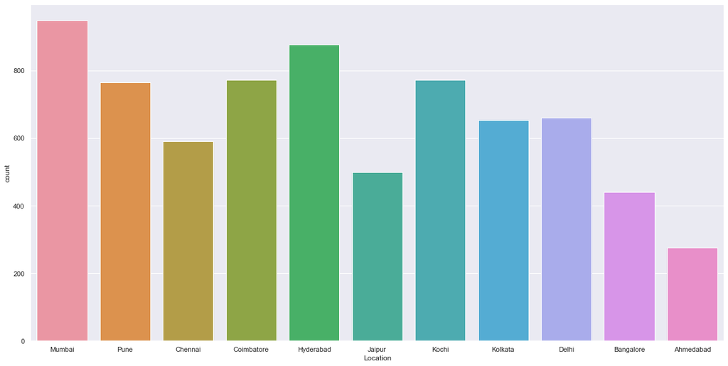

```python
# Let's see all the car locations in the data set
print(df.Location.value_counts())
plt.figure(figsize=(20, 10))
print(sns.countplot(df.Location))  # to visualize the distribution
```

#### Observation: Out of the 11 identified sales locations, Mumbai is the most popular with highest number(949) of used cars sales while Ahmedabad is the least popular

## Year

#### As earlier said, Year will be converted to Car_Age variable later for better processing

```python
df["Car_Age"] = (
    2021 - df.Year
)  # To change Year to Car_Age in years by subtracting the year of manufacture from the current year which is 2021
```

```python
df.sample(10)  # To sample 10 rows and see the new column 'Car_Age'
```

|  | Name | Location | Year | Kilometers_Driven | Fuel_Type | Transmission | Owner_Type | Mileage | Engine | Power | Seats | Price | Car_Age |
| --- | --- | --- | --- | --- | --- | --- | --- | --- | --- | --- | --- | --- | --- |
| 6645 | Hyundai | Hyderabad | 2009 | 52008 | Petrol | Manual | First | 15.3 kmpl | 1341 CC | 83 bhp | 5.0 | NaN | 12 |
| 1731 | Ford | Kolkata | 2012 | 60000 | Diesel | Manual | First | 20.0 kmpl | 1399 CC | 68 bhp | 5.0 | 2.10 | 9 |
| 6272 | Audi | Kochi | 2016 | 55331 | Diesel | Automatic | First | 17.68 kmpl | 1968 CC | 174.33 bhp | 5.0 | NaN | 5 |
| 3740 | Honda | Hyderabad | 2007 | 91000 | Petrol | Manual | Second | 17.7 kmpl | 1497 CC | 78 bhp | 5.0 | 3.00 | 14 |
| 7229 | Volkswagen | Mumbai | 2011 | 67500 | Petrol | Automatic | Second | 14.4 kmpl | 1598 CC | 103.6 bhp | 5.0 | NaN | 10 |
| 2768 | Mahindra | Kolkata | 2011 | 51387 | Diesel | Manual | First | 12.05 kmpl | 2179 CC | 120 bhp | 7.0 | 5.50 | 10 |
| 3792 | Hyundai | Hyderabad | 2016 | 30000 | Petrol | Manual | First | 21.1 kmpl | 814 CC | 55.2 bhp | 5.0 | 3.25 | 5 |
| 769 | Tata | Hyderabad | 2016 | 73000 | Diesel | Manual | First | 25.0 kmpl | 1396 CC | 69 bhp | 5.0 | 2.20 | 5 |
| 6162 | Ford | Jaipur | 2008 | 135000 | Diesel | Manual | First | 17.8 kmpl | 1399 CC | NaN | 5.0 | NaN | 13 |
| 1823 | Hyundai | Ahmedabad | 2014 | 49000 | Diesel | Automatic | First | 18.23 kmpl | 1582 CC | 126.2 bhp | 5.0 | 8.90 | 7 |

```python
# Now let's drop the Year column as it is no longer needed
df.drop(["Year"], axis=1, inplace=True)
```

```
6     929
7     925
5     886
8     791
4     709
9     690
10    579
11    407
3     361
12    252
13    207
14    148
2     119
15     89
16     68
17     35
18     20
19     18
20      8
21      5
23      4
22      2
25      1
Name: Car_Age, dtype: int64
AxesSubplot(0.125,0.125;0.775x0.755)
```

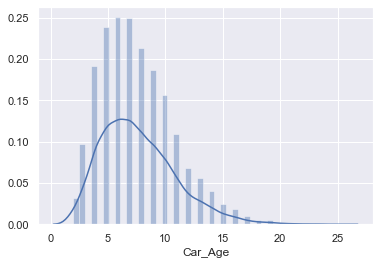

```python
print(df.Car_Age.value_counts())  # To see the frequency distribution of the car age
print(sns.distplot(df.Car_Age))  # To visualise the data
```

#### Obervation: It is obvious that more recent cars are in higher demand than the older ones. Used cars aged between 2-14 years sold more than older ones(20 years and above) with 6 years old cars topping the chart. The KDE of the distribution shows it is right skewed as well

## Fuel Type

#### Let's look at the fuel types available in the data set

```
Diesel      3852
Petrol      3325
CNG           62
LPG           12
Electric       2
Name: Fuel_Type, dtype: int64
AxesSubplot(0.125,0.125;0.775x0.755)
```

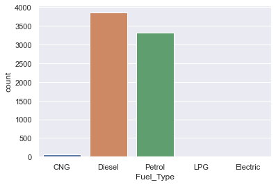

```python
print(df.Fuel_Type.value_counts())  # To check all the fuel types in the dataset
print(sns.countplot(df.Fuel_Type))  # To visualise the data
```

#### Observation: Used Cars of the fuel types Diesel and Petrol are the most sold with Diesel cars selling most. Used Electric cars are still least sold

## Transmission

```
Manual       5204
Automatic    2049
Name: Transmission, dtype: int64
AxesSubplot(0.125,0.125;0.775x0.755)
```

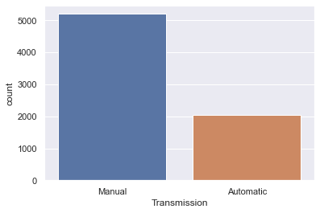

```python
print(
    df.Transmission.value_counts()
)  # To check all the Transmission types in the dataset
print(sns.countplot(df.Transmission))  # To visualise the data
```

#### Observation: Used cars with manual transmission sold more than the automatic transmision. More than 71% of cars sold have manual transmission

## Owner_Type

```
First             5952
Second            1152
Third              137
Fourth & Above      12
Name: Owner_Type, dtype: int64
AxesSubplot(0.125,0.125;0.775x0.755)
```

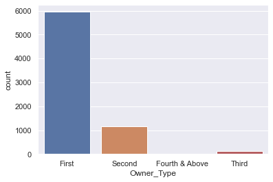

```python
print(df.Owner_Type.value_counts())  # To check all the Owner types in the dataset
print(sns.countplot(df.Owner_Type))  # To visualise the distribution
```

#### Observation: Used Cars with first owner type sold the most(82%) while the ones with Fourth & Above owner type are the least sold

## Mileage, Engine, and Power

#### Let's convert Mileage, Engine, and Power to float data type by removing the string attached to their observations

```python
# We shall use a defined function ofr this
def str_to_num(col_val):
    if isinstance(col_val, str):
        return float(col_val.split(" ")[0])
    else:
        return np.nan


str_col = ["Mileage", "Engine", "Power"]
for colname in str_col:
    df[colname] = df[colname].apply(str_to_num)
```

```python
df.sample(10)  # Let's sample 10 rows from the data to see what we just did above
```

|  | Name | Location | Kilometers_Driven | Fuel_Type | Transmission | Owner_Type | Mileage | Engine | Power | Seats | Price | Car_Age |
| --- | --- | --- | --- | --- | --- | --- | --- | --- | --- | --- | --- | --- |
| 5241 | Ford | Hyderabad | 21800 | Petrol | Manual | First | 17.00 | 1497.0 | 121.36 | 5.0 | 8.75 | 4 |
| 7161 | Volvo | Coimbatore | 90904 | Diesel | Automatic | First | 9.00 | 1984.0 | 181.00 | 5.0 | NaN | 5 |
| 6812 | Maruti | Hyderabad | 81814 | Petrol | Manual | First | 16.10 | 1298.0 | 88.20 | 5.0 | NaN | 13 |
| 6007 | Maruti | Delhi | 68000 | Diesel | Manual | First | 19.30 | 1248.0 | 73.90 | 5.0 | 2.75 | 10 |
| 4248 | Chevrolet | Delhi | 76155 | Petrol | Manual | First | 18.60 | 1199.0 | 79.40 | 5.0 | 1.95 | 10 |
| 2385 | Hyundai | Hyderabad | 17000 | LPG | Manual | First | 13.45 | 1086.0 | 62.10 | 5.0 | 3.10 | 10 |
| 2421 | Hyundai | Pune | 68000 | Petrol | Manual | First | 17.01 | 1591.0 | 121.30 | 5.0 | 3.70 | 10 |
| 1045 | Hyundai | Coimbatore | 44178 | Petrol | Manual | First | 18.90 | 1197.0 | 82.00 | 5.0 | 5.88 | 5 |
| 7210 | Maruti | Jaipur | 19000 | Diesel | Manual | First | 24.30 | 1248.0 | 88.50 | 5.0 | NaN | 4 |
| 1412 | Tata | Mumbai | 43706 | Petrol | Manual | First | 17.57 | 1193.0 | 88.70 | 5.0 | 4.00 | 5 |

## Seats

```
5.0     6047
7.0      796
8.0      170
4.0      119
6.0       38
2.0       18
10.0       8
9.0        3
0.0        1
Name: Seats, dtype: int64
AxesSubplot(0.125,0.125;0.775x0.755)
```

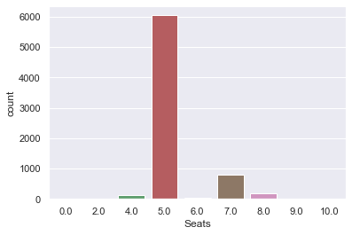

```python
print(df.Seats.value_counts())  # To check all the seat types in the dataset
print(sns.countplot(df.Seats))  # To visualise the data
```

#### Observation: The highest sold Used Cars are the 5 seaters. While zero seater sold the least. However, from domain knowledge, zero seater car doesn't exist. This might also speak to missingness. However, let's look at that row closely

```python
df[df["Seats"] == 0.0]  # To print the row contain zero seater car
```

|  | Name | Location | Kilometers_Driven | Fuel_Type | Transmission | Owner_Type | Mileage | Engine | Power | Seats | Price | Car_Age |
| --- | --- | --- | --- | --- | --- | --- | --- | --- | --- | --- | --- | --- |
| 3999 | Audi | Hyderabad | 125000 | Petrol | Automatic | First | 10.5 | 3197.0 | NaN | 0.0 | 18.0 | 9 |

#### Observation: The car with zero seat is an Audi car with automatic transmission. From domain knowledge, automatic transmission cars will at least have a seat for the driver. Therefore we will simply drop this row since it cannot have significant effect on the project objective

```python
df.drop(
    df.index[df["Seats"] == 0.0], inplace=True
)  # To drop that row containing the zero seat entry
```

```python
df[
    "Seats"
].value_counts()  # To check the remaining unique values after that row was dropped
```

```
5.0     6047
7.0      796
8.0      170
4.0      119
6.0       38
2.0       18
10.0       8
9.0        3
Name: Seats, dtype: int64
```

## Let's deal with the missing numbers

#### We will fill the missing values in the independent variables with their median since median is less susceptible to outliers and drop the ones in our target variable (Price)

```python
# Let check for missing values again
df.isnull().sum()
```

```
Name                    0
Location                0
Kilometers_Driven       0
Fuel_Type               0
Transmission            0
Owner_Type              0
Mileage                 2
Engine                 46
Power                 174
Seats                  53
Price                1234
Car_Age                 0
dtype: int64
```

```python
# Let us fill the missing values in the numeric independent variables with their median since median is less susceptible to outliers
numcol = ["Mileage", "Engine", "Power", "Seats"]

for colname in numcol:
    df[colname] = df[colname].fillna(df[colname].median())
```

```python
df.isnull().sum()  # To check the remaining missing values
```

```
Name                    0
Location                0
Kilometers_Driven       0
Fuel_Type               0
Transmission            0
Owner_Type              0
Mileage                 0
Engine                  0
Power                   0
Seats                   0
Price                1234
Car_Age                 0
dtype: int64
```

```python
# Let's drop the the missing values in our target variable 'Price' since it is the only variable left with missing values
df_new = df.dropna()
```

```python
df_new.isnull().sum()  # To check if there still exists any other missing values in the dataframe
```

```
Name                 0
Location             0
Kilometers_Driven    0
Fuel_Type            0
Transmission         0
Owner_Type           0
Mileage              0
Engine               0
Power                0
Seats                0
Price                0
Car_Age              0
dtype: int64
```

#### Observation: No more missingness in the data set

## Conversion to category data type

#### "Location", "Fuel_Type", "Transmission", "Owner_Type", and "CarBrand" are identified as categorical variable while others are numeric. However, we will convert them and 'Seats' to categorical data type now.

```python
cat_vars = [
    "Location",
    "Fuel_Type",
    "Transmission",
    "Owner_Type",
    "Name",
    "Seats",
]  # Defining the variables to make categorical

for colname in cat_vars:
    df_new[colname] = df_new[colname].astype(
        "category"
    )  # To make the variables catogorical

df_new.info()
```

```
<class 'pandas.core.frame.DataFrame'>
Int64Index: 6018 entries, 0 to 6018
Data columns (total 12 columns):
 #   Column             Non-Null Count  Dtype
---  ------             --------------  -----
 0   Name               6018 non-null   category
 1   Location           6018 non-null   category
 2   Kilometers_Driven  6018 non-null   int64
 3   Fuel_Type          6018 non-null   category
 4   Transmission       6018 non-null   category
 5   Owner_Type         6018 non-null   category
 6   Mileage            6018 non-null   float64
 7   Engine             6018 non-null   float64
 8   Power              6018 non-null   float64
 9   Seats              6018 non-null   category
 10  Price              6018 non-null   float64
 11  Car_Age            6018 non-null   int64
dtypes: category(6), float64(4), int64(2)
memory usage: 366.9 KB
```

## Statistical Summary of numeric variables

```python
df_new.describe().T  # Let's look at the statistical summary of the numerical variables
```

|  | count | mean | std | min | 25% | 50% | 75% | max |
| --- | --- | --- | --- | --- | --- | --- | --- | --- |
| Kilometers_Driven | 6018.0 | 58727.369724 | 91272.429192 | 171.00 | 34000.0000 | 53000.00 | 73000.00 | 6500000.00 |
| Mileage | 6018.0 | 18.136238 | 4.580851 | 0.00 | 15.1775 | 18.16 | 21.10 | 33.54 |
| Engine | 6018.0 | 1620.247258 | 599.340739 | 72.00 | 1198.0000 | 1493.00 | 1969.00 | 5998.00 |
| Power | 6018.0 | 112.798757 | 53.315607 | 34.20 | 78.0000 | 94.00 | 138.03 | 560.00 |
| Price | 6018.0 | 9.478053 | 11.188307 | 0.44 | 3.5000 | 5.64 | 9.95 | 160.00 |
| Car_Age | 6018.0 | 7.641575 | 3.269967 | 2.00 | 5.0000 | 7.00 | 10.00 | 23.00 |

#### Observations:

#### Aside Mileage which has almost normal distribution because mean and median values are alomst the same, the other variables' distributions are all right skewed

#### It is obvious that Kilometers_Driven is heavily skewed to the right as the minimum value 171 and even the 75th Percentile are too far away from the maximum value coupled with the fact the the mean is greater than the median. The maximum value 6,500,000 is obviously not real going by naturally knowledge of Kilometers a vehicle can run in its lifetime

#### Therefore we need to investigate this further and probably drop that row containing 6,500,000

## Some Bivariate Analysis

```
                   Kilometers_Driven   Mileage    Engine     Power     Price  \
Kilometers_Driven           1.000000 -0.065070  0.090629  0.031797 -0.011586
Mileage                    -0.065070  1.000000 -0.586149 -0.495569 -0.306462
Engine                      0.090629 -0.586149  1.000000  0.861175  0.657424
Power                       0.031797 -0.495569  0.861175  1.000000  0.770142
Price                      -0.011586 -0.306462  0.657424  0.770142  1.000000
Car_Age                     0.173008 -0.321497  0.049934 -0.026610 -0.305399

                    Car_Age
Kilometers_Driven  0.173008
Mileage           -0.321497
Engine             0.049934
Power             -0.026610
Price             -0.305399
Car_Age            1.000000
```

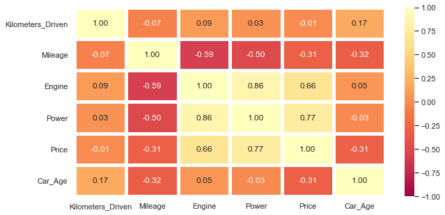

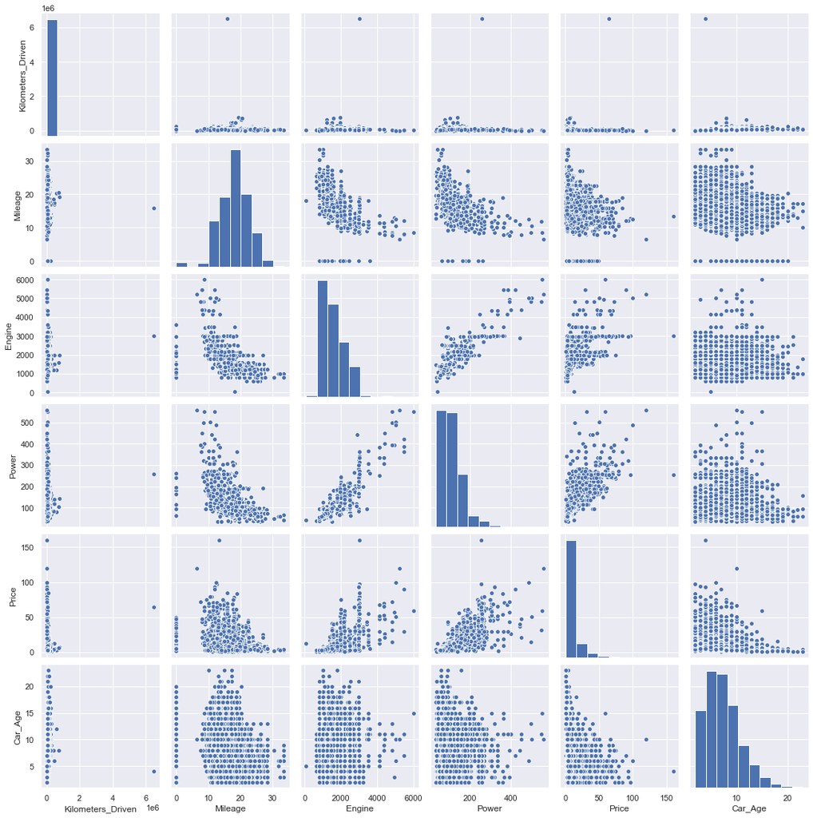

```python
print(
    df_new.corr()
)  # Let's look at the correlation between pairs of all numerical variables in the data set

# we shall plot the heatmap of the correlation ratio among the numerical data
plt.figure(figsize=(10, 5))
sns.heatmap(
    df_new.corr(),
    annot=True,
    linewidth=5,
    vmin=-1,
    vmax=1,
    fmt=".2f",
    center=1,
    cmap="Spectral",
)
plt.show()

sns.pairplot(
    df_new[["Kilometers_Driven", "Mileage", "Engine", "Power", "Price", "Car_Age"]]
)
# To visualise these relationships between pairs of all mentioned variables in the data set
```

#### Observation: There appears to be strongest positive relationships between Engine and Power while Price and Power also have a strong positve relationship. This means that an increase in one will often witness an increase in the other. However, the strongest negative relationship exists between Car Engine displacement and Mileage. The relationship between these numeric variables are also displayed in the various scatterplots shown above.

### Name Vs Price

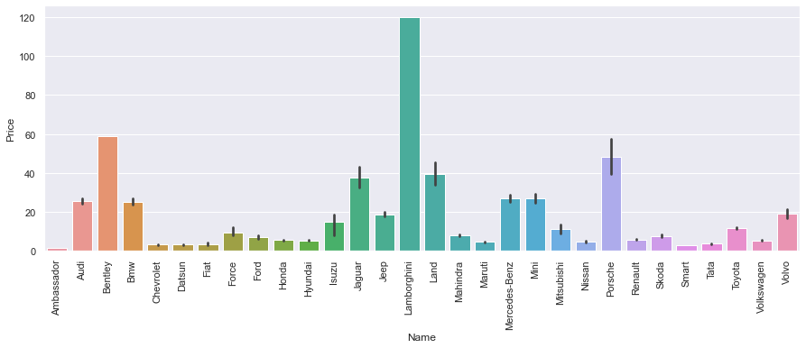

```python
plt.figure(figsize=(15, 5))
sns.barplot(x="Name", y="Price", data=df_new)
plt.xticks(rotation=90)
plt.show()
```

#### Observation: Lamborghini is the most expensive car among the car brands in the data set. Bentley and Porsche are also more expensive than the remaining brands

### Location Vs Price

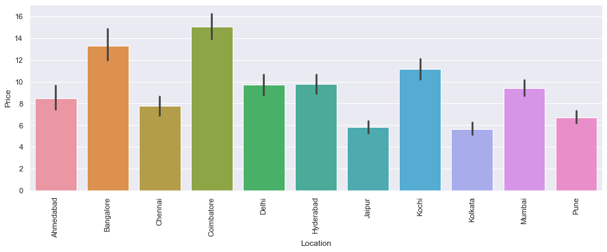

```python
plt.figure(figsize=(15, 5))
sns.barplot(x="Location", y="Price", data=df_new)
plt.xticks(rotation=90)
plt.show()
```

#### Observation: It can be observed from the bar chart above that Location Coimbatore sells more expensive used cars than any other locations. Used Car Price at Kolkata is generally low

### Fuel_Type Vs Price

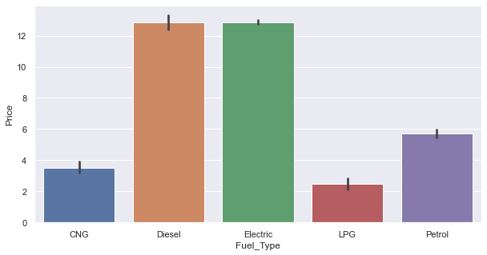

```python
plt.figure(figsize=(10, 5))
sns.barplot(x="Fuel_Type", y="Price", data=df_new)
plt.show()
```

#### Observation: It appears that highly priced used cars are majorly Diesel and Electric cars while LPG Cars are generally the cheapest

### Transmission Vs Price

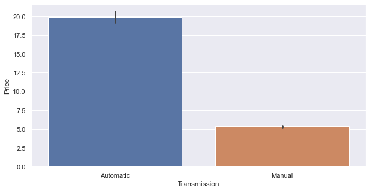

```python
plt.figure(figsize=(10, 5))
sns.barplot(x="Transmission", y="Price", data=df_new)
plt.show()
```

#### Observation: Automatic Cars are priced more than 300% of the prices of manual cars

### Owner_Type Vs Price

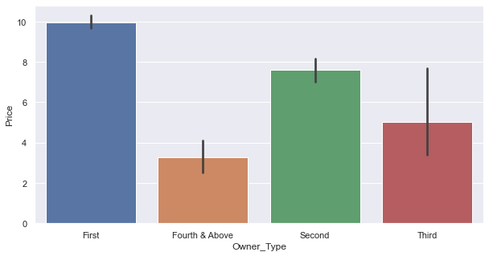

```python
plt.figure(figsize=(10, 5))
sns.barplot(x="Owner_Type", y="Price", data=df_new)
plt.show()
```

#### Observation: Used cars of first owner type are priced higher than other categories. Interestingly, the price of the used cars decrease with increasing number of Owner_type

### Seats Vs Price

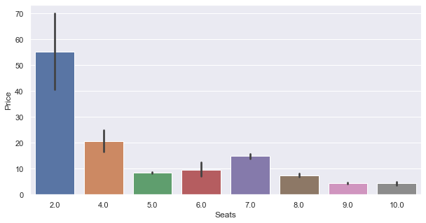

```python
plt.figure(figsize=(10, 5))
sns.barplot(x="Seats", y="Price", data=df_new)
plt.show()
```

## Distributions of the Numeric Variables

### Lets plot both Histogram and boxplot of each of the numeric variable to visualise their distributions

```python
##let's define a functionn for plotting both histogram and boxplot
def hist_boxplt(data, figsize=(15, 7), kde=True, bins=None):

    f2, (ax_box2, ax_hist2) = plt.subplots(
        nrows=2,  # Number of rows of the subplot grid= 2
        sharex=True,  # x-axis will be shared among all subplots
        gridspec_kw={"height_ratios": (0.25, 0.75)},
        figsize=figsize,
    )  # creating the 2 subplots
    sns.boxplot(
        data, ax=ax_box2, showmeans=True, color="violet"
    )  # boxplot will be created and a star will indicate the mean value of the column
    sns.distplot(
        data, kde=kde, ax=ax_hist2, bins=bins, palette="winter"
    ) if bins else sns.distplot(
        data, kde=kde, ax=ax_hist2
    )  # For histogram
    ax_hist2.axvline(
        data.mean(), color="green", linestyle="--"
    )  # Add mean to the histogram
    ax_hist2.axvline(
        data.median(), color="black", linestyle="-"
    )  # Add median to the histogram
```

### Kilometers_Driven

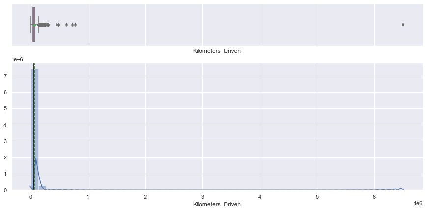

```python
hist_boxplt(df_new.Kilometers_Driven)
```

#### Observation: Both the boxplot and histogram further confirms a heavy skewness to the right with some distant outliers

```python
# let's look at the row with that maximum kilometers_Driven then remove the row i.e that maximum number 6,500,000 and visualise again
df_new[df_new.Kilometers_Driven == 6500000]
```

|  | Name | Location | Kilometers_Driven | Fuel_Type | Transmission | Owner_Type | Mileage | Engine | Power | Seats | Price | Car_Age |
| --- | --- | --- | --- | --- | --- | --- | --- | --- | --- | --- | --- | --- |
| 2328 | Bmw | Chennai | 6500000 | Diesel | Automatic | First | 15.97 | 2993.0 | 258.0 | 5.0 | 65.0 | 4 |

#### Observation:

#### A BMW car made in 2017 couldn't have run 6,500,000 kilometers in 4 years. It is therefore an error in the data collation process and needs to be dropped

```python
# Therefore let's drop that row
df_new.drop(df_new.index[df_new.Kilometers_Driven == 6500000], inplace=True)
```

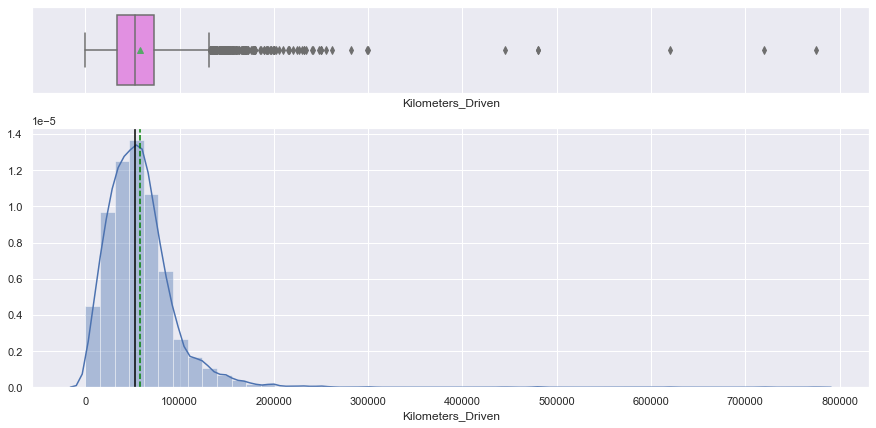

```python
hist_boxplt(df_new.Kilometers_Driven)  # To visualise the Kilometers_Driven again
```

#### Observation:

#### The distribution is still very skewed to the right. Let's apply the log transformation and see whether it will behave better

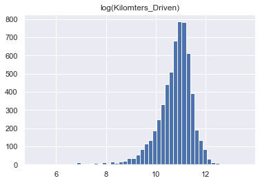

```python
plt.hist(np.log(df_new["Kilometers_Driven"] + 1), 50)
plt.title("log(Kilomters_Driven)")
plt.show()
```

#### Observation:The log transformation decreases the scale of the distributions, even with the huge range of Kilometers_Driven. It seems the outliers caused the log-transformed distribution to still be a bit skewed, but it is closer to normal than the original distribution.

## Mileage

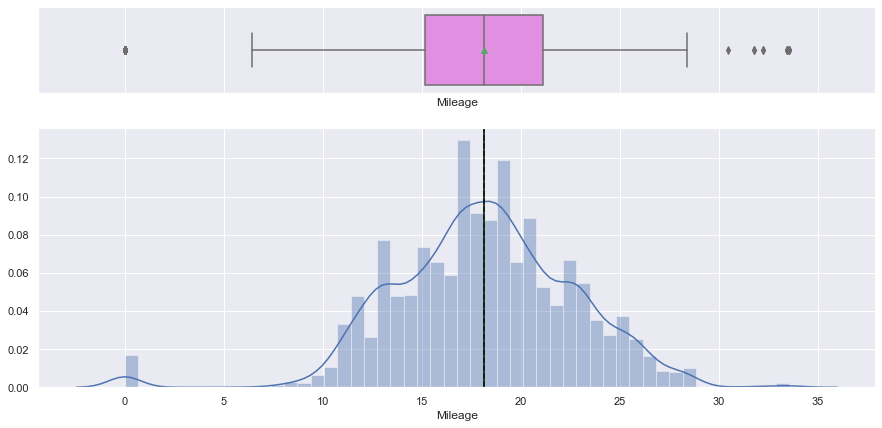

```python
hist_boxplt(df_new.Mileage)
```

#### Observation: Mileage distrbution is close to normal as earlier seen from the statistical summary aside the few outliers on both sides

## Engine

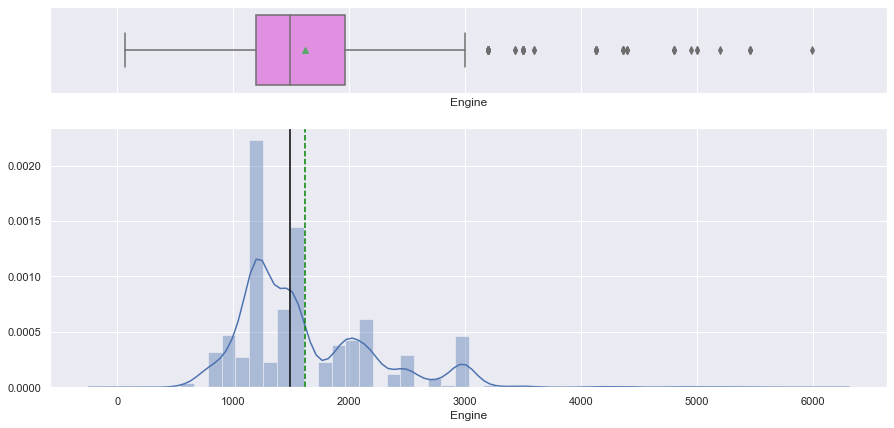

```python
hist_boxplt(df_new.Engine)
```

#### Observation: This is also very skewed to the right. We will apply log transformation to the distribution also and see its behaviour afterwhats

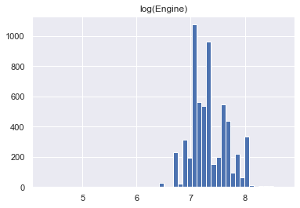

```python
plt.hist(np.log(df_new["Engine"] + 1), 50)
plt.title("log(Engine)")
plt.show()
```

#### Log transformation also helps here

## Power

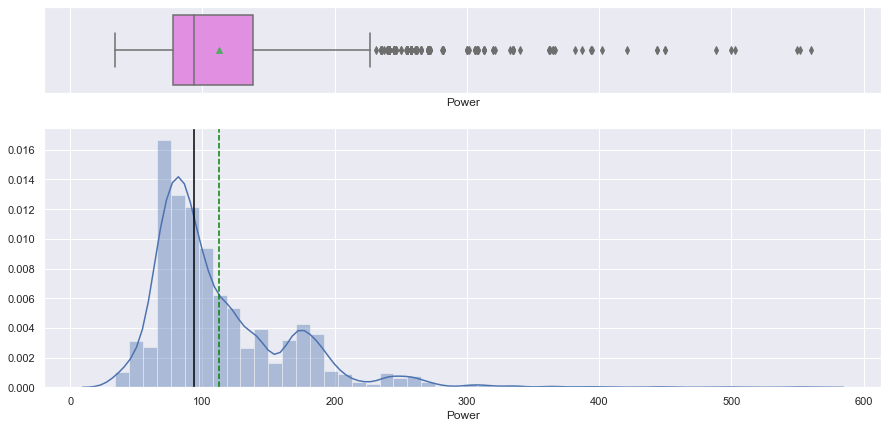

```python
hist_boxplt(df_new.Power)
```

#### Observation: This is also very skewed to the right. We will apply log transformation to the distribution also and see its behaviour too

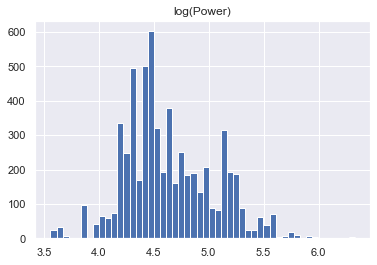

```python
plt.hist(
    np.log(df_new["Power"] + 1), 50
)  # To apply log transformation to Power distribution
plt.title("log(Power)")
plt.show()
```

#### Log transformation also helps here

## Car_Age

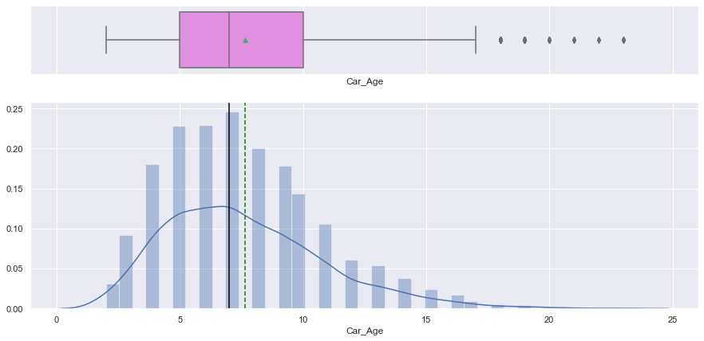

```python
hist_boxplt(df_new.Car_Age)
```

#### The Car_Age distribution is also right skewed. Therefore let's apply log transformation to it too so as to deal with the skewness

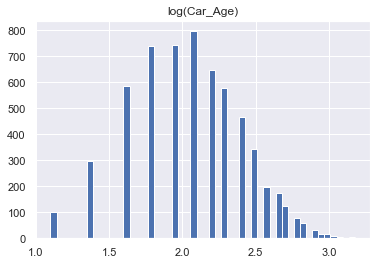

```python
plt.hist(
    np.log(df_new["Car_Age"] + 1), 50
)  # To apply log transformation to Car_Age distribution
plt.title("log(Car_Age)")
plt.show()
```

#### It seems the log transformation also helps a bit on the Car_Age distribution

### Now let's bind the log- transformed data to the dataframe and drop the initially columns

```python
cols_to_log = [
    "Kilometers_Driven",
    "Engine",
    "Power",
    "Car_Age",
]  # These are the columns which we have performed log transformation on
for colname in cols_to_log:
    df_new[colname + "_log"] = np.log(
        df_new[colname]
    )  # To bind the log-transformed data to the dataframe
df_new.drop(
    cols_to_log, axis=1, inplace=True
)  # To drop the initial columns containing the transformed data
```

```python
df_new.sample(10)
```

|  | Name | Location | Fuel_Type | Transmission | Owner_Type | Mileage | Seats | Price | Kilometers_Driven_log | Engine_log | Power_log | Car_Age_log |
| --- | --- | --- | --- | --- | --- | --- | --- | --- | --- | --- | --- | --- |
| 3577 | Hyundai | Delhi | Diesel | Automatic | First | 22.70 | 5.0 | 6.80 | 11.170435 | 7.366445 | 4.837868 | 2.079442 |
| 3695 | Honda | Hyderabad | Petrol | Automatic | First | 18.00 | 5.0 | 11.50 | 9.546813 | 7.311218 | 4.764735 | 1.609438 |
| 5607 | Volkswagen | Pune | Diesel | Automatic | Second | 16.96 | 5.0 | 11.50 | 11.087054 | 7.584773 | 4.927471 | 1.791759 |
| 2452 | Hyundai | Mumbai | Diesel | Manual | First | 25.40 | 5.0 | 3.55 | 11.141862 | 7.078342 | 4.303660 | 1.386294 |
| 3065 | Mercedes-Benz | Mumbai | Petrol | Automatic | First | 10.93 | 5.0 | 10.40 | 11.198215 | 8.159947 | 5.605802 | 2.397895 |
| 5425 | Hyundai | Kochi | Diesel | Manual | First | 24.00 | 5.0 | 4.90 | 10.975020 | 7.021084 | 4.248495 | 1.791759 |
| 1671 | Maruti | Coimbatore | Petrol | Manual | Second | 18.60 | 5.0 | 6.26 | 9.803336 | 7.087574 | 4.452019 | 1.609438 |
| 3753 | Hyundai | Mumbai | Diesel | Manual | First | 24.00 | 5.0 | 4.61 | 11.183087 | 7.021084 | 4.248495 | 2.079442 |
| 1572 | Hyundai | Kolkata | Diesel | Manual | First | 22.32 | 5.0 | 4.30 | 10.373491 | 7.366445 | 4.838660 | 1.945910 |
| 597 | Mitsubishi | Mumbai | Diesel | Manual | Third | 10.50 | 6.0 | 5.45 | 11.440355 | 7.949797 | 4.674696 | 2.564949 |

#### Observation: Now we have a clean data and we can now commence model building

## Model Building

### Defining the dependent and independent variables

```python
x = df_new.drop(
    ["Price"], axis=1
)  # defining the independent variables to refer to all other variables in the dataset aside 'Price'
y = df_new["Price"]  # defining the dependent variable to be 'Price' of used car
```

### Creating dummy variables from the categorical variables

```python
x = pd.get_dummies(
    x,
    columns=x.select_dtypes(include=["category"]).columns.tolist(),
    drop_first=True
)# To encode the categorical columns in the dataframe and drop the first dummy column in each variable
x.head()
```

|  | Mileage | Kilometers_Driven_log | Engine_log | Power_log | Car_Age_log | Name_Audi | Name_Bentley | Name_Bmw | Name_Chevrolet | Name_Datsun | Name_Fiat | Name_Force | Name_Ford | Name_Honda | Name_Hyundai | Name_Isuzu | Name_Jaguar | Name_Jeep | Name_Lamborghini | Name_Land | Name_Mahindra | Name_Maruti | Name_Mercedes-Benz | Name_Mini | Name_Mitsubishi | Name_Nissan | Name_Porsche | Name_Renault | Name_Skoda | … |
| --- | --- | --- | --- | --- | --- | --- | --- | --- | --- | --- | --- | --- | --- | --- | --- | --- | --- | --- | --- | --- | --- | --- | --- | --- | --- | --- | --- | --- | --- | --- |
| 0 | 26.60 | 11.184421 | 6.905753 | 4.063198 | 2.397895 | 0 | 0 | 0 | 0 | 0 | 0 | 0 | 0 | 0 | 0 | 0 | 0 | 0 | 0 | 0 | 0 | 1 | 0 | 0 | 0 | 0 | 0 | 0 | 0 | … |
| 1 | 19.67 | 10.621327 | 7.366445 | 4.837868 | 1.791759 | 0 | 0 | 0 | 0 | 0 | 0 | 0 | 0 | 0 | 1 | 0 | 0 | 0 | 0 | 0 | 0 | 0 | 0 | 0 | 0 | 0 | 0 | 0 | 0 | … |
| 2 | 18.20 | 10.736397 | 7.089243 | 4.485260 | 2.302585 | 0 | 0 | 0 | 0 | 0 | 0 | 0 | 0 | 1 | 0 | 0 | 0 | 0 | 0 | 0 | 0 | 0 | 0 | 0 | 0 | 0 | 0 | 0 | 0 | … |
| 3 | 20.77 | 11.373663 | 7.129298 | 4.485936 | 2.197225 | 0 | 0 | 0 | 0 | 0 | 0 | 0 | 0 | 0 | 0 | 0 | 0 | 0 | 0 | 0 | 0 | 1 | 0 | 0 | 0 | 0 | 0 | 0 | 0 | … |
| 4 | 15.20 | 10.613246 | 7.584773 | 4.947340 | 2.079442 | 1 | 0 | 0 | 0 | 0 | 0 | 0 | 0 | 0 | 0 | 0 | 0 | 0 | 0 | 0 | 0 | 0 | 0 | 0 | 0 | 0 | 0 | 0 | 0 | … |

```python
x.shape
```

```
(6017, 59)
```

### Splitting the data into train and test data sets

```python
x_train, x_test, y_train, y_test = train_test_split(
    x, y, test_size=0.30, random_state=1
)  # To split the data into 70% train data and 30% test data
```

```python
# Let's see the number of rows in both train and test data
print("Number of rows in train data =", x_train.shape[0])
print("Number of rows in test data =", x_test.shape[0])
```

```
Number of rows in train data = 4211
Number of rows in test data = 1806
```

### Let's fit the Linear Regression Model

```python
reg = LinearRegression()
reg.fit(x_train, y_train)
```

```
LinearRegression(copy_X=True, fit_intercept=True, n_jobs=None, normalize=False)
```

### Let us check the coefficients and intercept of the model, which are the parameters we learned

```python
coef_df = pd.DataFrame(
    np.append(reg.coef_, reg.intercept_),
    index=x_train.columns.tolist() + ["Intercept"],
    columns=["Coefficients"],
)
coef_df
```

|  | Coefficients |
| --- | --- |
| Mileage | -0.096458 |
| Kilometers_Driven_log | -1.208291 |
| Engine_log | 4.279273 |
| Power_log | 6.690133 |
| Car_Age_log | -6.739407 |
| Name_Audi | 4.991958 |
| Name_Bentley | 23.818529 |
| Name_Bmw | 4.176853 |
| Name_Chevrolet | -7.558098 |
| Name_Datsun | -9.163107 |
| Name_Fiat | -7.654607 |
| Name_Force | -10.820586 |
| Name_Ford | -7.005548 |
| Name_Honda | -7.928776 |
| Name_Hyundai | -7.118999 |
| Name_Isuzu | -13.660194 |
| Name_Jaguar | 13.704755 |
| Name_Jeep | -6.669090 |
| Name_Lamborghini | 67.827328 |
| Name_Land | 16.175653 |
| Name_Mahindra | -11.776630 |
| Name_Maruti | -6.149293 |
| Name_Mercedes-Benz | 5.088901 |
| Name_Mini | 4.116056 |
| Name_Mitsubishi | -7.742777 |
| Name_Nissan | -7.035613 |
| Name_Porsche | 17.572664 |
| Name_Renault | -7.594339 |
| Name_Skoda | -7.021984 |
| Name_Smart | -26.151411 |
| Name_Tata | -9.408061 |
| Name_Toyota | -6.941285 |
| Name_Volkswagen | -7.652735 |
| Name_Volvo | -0.972208 |
| Location_Bangalore | 2.253491 |
| Location_Chennai | 0.940775 |
| Location_Coimbatore | 1.953266 |
| Location_Delhi | -0.444432 |
| Location_Hyderabad | 1.643207 |
| Location_Jaipur | 0.821800 |
| Location_Kochi | -0.570463 |
| Location_Kolkata | -1.421500 |
| Location_Mumbai | -0.630442 |
| Location_Pune | 0.354010 |
| Fuel_Type_Diesel | -0.096348 |
| Fuel_Type_Electric | 9.932433 |
| Fuel_Type_LPG | 1.626944 |
| Fuel_Type_Petrol | -1.155554 |
| Transmission_Manual | 0.046938 |
| Owner_Type_Fourth & Above | -1.648800 |
| Owner_Type_Second | -0.565497 |
| Owner_Type_Third | -0.133941 |
| Seats_4.0 | -14.363512 |
| Seats_5.0 | -21.893435 |
| Seats_6.0 | -20.557485 |
| Seats_7.0 | -18.777237 |
| Seats_8.0 | -20.107651 |
| Seats_9.0 | -21.635017 |
| Seats_10.0 | -21.652849 |
| Intercept | 1.696991 |

### Model performance check

- We will be using metric functions defined in sklearn for RMSE, MAE, and $R^2$.
- We will define functions to calculate adjusted $R^2$ and MAPE.
- We will create a function that will print out all the above metrics in one go.

```python
# function to compute adjusted R-squared
def cal_adj_r2(predictors, targets, predictions):
    r2 = r2_score(targets, predictions)
    n = predictors.shape[0]
    k = predictors.shape[1]
    return 1 - ((1 - r2) * (n - 1) / (n - k - 1))


# function to compute MAPE
def cal_mape(targets, predictions):
    return np.mean(np.abs(targets - predictions) / targets) * 100


# function to compute different metrics to check performance of a regression model
def model_perf_reg(model, predictors, target):

    # predicting using the independent variables
    pred = model.predict(predictors)

    r2 = r2_score(target, pred)  # to compute R-squared
    adjr2 = cal_adj_r2(predictors, target, pred)  # to compute adjusted R-squared
    rmse = np.sqrt(mean_squared_error(target, pred))  # to compute RMSE
    mae = mean_absolute_error(target, pred)  # to compute MAE
    mape = cal_mape(target, pred)  # to compute MAPE

    # creating a dataframe of metrics
    df_perf = pd.DataFrame(
        {
            "RMSE": rmse,
            "MAE": mae,
            "R-squared": r2,
            "Adj. R-squared": adjr2,
            "MAPE": mape,
        },
        index=[0],
    )

    return df_perf
```

```python
# Checking model performance on train set
print("Training Performance\n")
model_train_perf = model_perf_reg(reg, x_train, y_train)
model_train_perf
```

```
Training Performance
```

|  | RMSE | MAE | R-squared | Adj. R-squared | MAPE |
| --- | --- | --- | --- | --- | --- |
| 0 | 5.544911 | 3.036558 | 0.766985 | 0.763673 | 56.069635 |

```python
# Checking model performance on test set
print("Test Performance\n")
model_test_perf = model_perf_reg(reg, x_test, y_test)
model_test_perf
```

```
Test Performance
```

|  | RMSE | MAE | R-squared | Adj. R-squared | MAPE |
| --- | --- | --- | --- | --- | --- |
| 0 | 4.568176 | 2.876686 | 0.806208 | 0.799659 | 53.443599 |

**Observations**

- The train and test $R^2$ are 0.77 and 0.81 approximately, indicating that the model explains 77% and 81% of the total variation in the train and test sets respectively. Also, both scores are comparable.
- RMSE values on the train and test sets are also comparable.
- This shows that the model is not overfitting.
- MAE indicates that our current model is able to predict used car price within a mean error of 2.88
- MAPE of 53.4 on the test data means that we are able to predict within 53.4% of the used cars price.

### Using Forward Feature Selection

#### We shall use this to reduce the data dimensions and discard deceptive features

```python
from mlxtend.feature_selection import (
    SequentialFeatureSelector as SFS,
)  # To import relevant library for forward feature selection

reg = LinearRegression()

# Build step forward feature selection
sfs = SFS(
    reg,
    k_features=x_train.shape[1],
    forward=True,  # k_features denotes the number of features to select
    floating=False,
    scoring="r2",
    n_jobs=-1,  # n_jobs=-1 means all processor cores will be used
    verbose=2,
    cv=5,
)

# Perform SFFS
sfs = sfs.fit(x_train, y_train)
```

[output not shown]

[output cut: 143 more lines]

[output not shown]

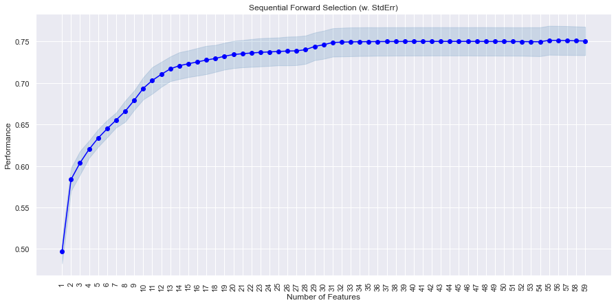

```python
# to plot the performance with addition of each feature
from mlxtend.plotting import plot_sequential_feature_selection as plot_sfs

fig1 = plot_sfs(sfs.get_metric_dict(), kind="std_err", figsize=(15, 7))
plt.title("Sequential Forward Selection (w. StdErr)")
plt.xticks(rotation=90)
plt.show()
```

- We can see that performance increases till the 31th feature and then slowly becomes constant, peaks at 55th feature and then drops slightly afterwhats.
- Now let's see if the model performance will be affected significantly if we select the first 55th features alone

```python
reg = LinearRegression()

# Build step forward feature selection
sfs = SFS(
    reg,
    k_features=55,
    forward=True,
    floating=False,
    scoring="r2",
    n_jobs=-1,
    verbose=2,
    cv=5,
)

# Perform SFFS
sfs = sfs.fit(x_train, y_train)
```

[output not shown]

[output cut: 127 more lines]

[output not shown]

```python
# let us select the features which are important
feat_cols = list(sfs.k_feature_idx_)
print(feat_cols)
```

```
[0, 1, 2, 3, 4, 5, 6, 7, 8, 9, 10, 11, 12, 13, 14, 15, 16, 17, 18, 19, 20, 21, 22, 23, 24, 25, 26, 27, 28, 29, 30, 31, 32, 33, 34, 35, 36, 38, 39, 41, 43, 45, 46, 47, 48, 49, 50, 51, 52, 53, 54, 55, 56, 57, 58]
```

```python
# let us look at the names of the important features
x_train.columns[feat_cols]
```

```
Index(['Mileage', 'Kilometers_Driven_log', 'Engine_log', 'Power_log',
       'Car_Age_log', 'Name_Audi', 'Name_Bentley', 'Name_Bmw',
       'Name_Chevrolet', 'Name_Datsun', 'Name_Fiat', 'Name_Force', 'Name_Ford',
       'Name_Honda', 'Name_Hyundai', 'Name_Isuzu', 'Name_Jaguar', 'Name_Jeep',
       'Name_Lamborghini', 'Name_Land', 'Name_Mahindra', 'Name_Maruti',
       'Name_Mercedes-Benz', 'Name_Mini', 'Name_Mitsubishi', 'Name_Nissan',
       'Name_Porsche', 'Name_Renault', 'Name_Skoda', 'Name_Smart', 'Name_Tata',
       'Name_Toyota', 'Name_Volkswagen', 'Name_Volvo', 'Location_Bangalore',
       'Location_Chennai', 'Location_Coimbatore', 'Location_Hyderabad',
       'Location_Jaipur', 'Location_Kolkata', 'Location_Pune',
       'Fuel_Type_Electric', 'Fuel_Type_LPG', 'Fuel_Type_Petrol',
       'Transmission_Manual', 'Owner_Type_Fourth & Above', 'Owner_Type_Second',
       'Owner_Type_Third', 'Seats_4.0', 'Seats_5.0', 'Seats_6.0', 'Seats_7.0',
       'Seats_8.0', 'Seats_9.0', 'Seats_10.0'],
      dtype='object')
```

```python
# Creating new x_train with the same 55 variables that we selected
x_train_final = x_train[x_train.columns[feat_cols]]
```

```python
# Creating new x_test with the same 55 variables that we selected for x_train
x_test_final = x_test[x_train_final.columns]
```

```python
# Fitting linear model
reg2 = LinearRegression()
reg2.fit(x_train_final, y_train)

# let us check the coefficients and intercept of the model

coef_df = pd.DataFrame(
    np.append(reg2.coef_.flatten(), reg2.intercept_),
    index=x_train_final.columns.tolist() + ["Intercept"],
    columns=["Coefficients"],
)
print(coef_df)
```

```
                           Coefficients
Mileage                       -0.096126
Kilometers_Driven_log         -1.195693
Engine_log                     4.254892
Power_log                      6.694760
Car_Age_log                   -6.730639
Name_Audi                      4.993191
Name_Bentley                  23.845012
Name_Bmw                       4.171989
Name_Chevrolet                -7.576101
Name_Datsun                   -9.165409
Name_Fiat                     -7.690856
Name_Force                   -10.828282
Name_Ford                     -7.034547
Name_Honda                    -7.935012
Name_Hyundai                  -7.116170
Name_Isuzu                   -13.651866
Name_Jaguar                   13.684698
Name_Jeep                     -6.690596
Name_Lamborghini              67.906387
Name_Land                     16.174390
Name_Mahindra                -11.779324
Name_Maruti                   -6.152239
Name_Mercedes-Benz             5.069343
Name_Mini                      4.065642
Name_Mitsubishi               -7.753572
Name_Nissan                   -7.074877
Name_Porsche                  17.531606
Name_Renault                  -7.617193
Name_Skoda                    -7.040707
Name_Smart                   -26.253258
Name_Tata                     -9.408519
Name_Toyota                   -6.931453
Name_Volkswagen               -7.670382
Name_Volvo                    -0.972885
Location_Bangalore             2.746825
Location_Chennai               1.431175
Location_Coimbatore            2.451974
Location_Hyderabad             2.130379
Location_Jaipur                1.310100
Location_Kolkata              -0.924440
Location_Pune                  0.848792
Fuel_Type_Electric             9.869884
Fuel_Type_LPG                  1.696556
Fuel_Type_Petrol              -1.086915
Transmission_Manual            0.051304
Owner_Type_Fourth & Above     -1.707308
Owner_Type_Second             -0.560610
Owner_Type_Third              -0.159496
Seats_4.0                    -14.405175
Seats_5.0                    -21.949068
Seats_6.0                    -20.630255
Seats_7.0                    -18.837089
Seats_8.0                    -20.176652
Seats_9.0                    -21.700038
Seats_10.0                   -21.760895
Intercept                      1.176845
```

```python
# model performance on train set
print("Training Performance\n")
reg2_model_train_perf = model_perf_reg(reg2, x_train_final, y_train)
reg2_model_train_perf
```

```
Training Performance
```

|  | RMSE | MAE | R-squared | Adj. R-squared | MAPE |
| --- | --- | --- | --- | --- | --- |
| 0 | 5.546035 | 3.038432 | 0.766891 | 0.763805 | 56.093412 |

```python
# model performance on test set
print("Test Performance\n")
reg2_model_test_perf = model_perf_reg(reg2, x_test_final, y_test)
reg2_model_test_perf
```

```
Test Performance
```

|  | RMSE | MAE | R-squared | Adj. R-squared | MAPE |
| --- | --- | --- | --- | --- | --- |
| 0 | 4.571059 | 2.88371 | 0.805963 | 0.799865 | 53.609996 |

```python
# training performance comparison

models_train_comp_df = pd.concat(
    [model_train_perf.T, reg2_model_train_perf.T],
    axis=1,
)

models_train_comp_df.columns = [
    "Linear Regression sklearn",
    "Linear Regression sklearn (SFS features)",
]

print("Training performance comparison:")
models_train_comp_df
```

```
Training performance comparison:
```

|  | Linear Regression sklearn | Linear Regression sklearn (SFS features) |
| --- | --- | --- |
| RMSE | 5.544911 | 5.546035 |
| MAE | 3.036558 | 3.038432 |
| R-squared | 0.766985 | 0.766891 |
| Adj. R-squared | 0.763673 | 0.763805 |
| MAPE | 56.069635 | 56.093412 |

```python
# test performance comparison

models_test_comp_df = pd.concat(
    [model_test_perf.T, reg2_model_test_perf.T],
    axis=1,
)

models_test_comp_df.columns = [
    "Linear Regression sklearn",
    "Linear Regression sklearn (SFS features)",
]

print("Test performance comparison:")
models_test_comp_df
```

```
Test performance comparison:
```

|  | Linear Regression sklearn | Linear Regression sklearn (SFS features) |
| --- | --- | --- |
| RMSE | 4.568176 | 4.571059 |
| MAE | 2.876686 | 2.883710 |
| R-squared | 0.806208 | 0.805963 |
| Adj. R-squared | 0.799659 | 0.799865 |
| MAPE | 53.443599 | 53.609996 |